# Assignment 1

2024-05-13

## Research question

In this report I aim to investigate how the distribution of types of alcohol consumed over time across different countries has changed. In particular I wish to explore how the trends have overall changed and which countries differ from this trend.

```r
#Load the data
data_alcohol <- read.csv("Data/alcohol-by-type-1890.csv")
#Remove 'CODE' as this is an extraneous variable
data_alcohol = subset(data_alcohol, select = -c(2))
data_alcohol2 = data_alcohol
#Rename some variables for ease of reading
names(data_alcohol2) <- c("Country", "Year", "SpiritsPercentage","BeerPercentage","WinePercentage")
```

## Data Introduction

This dataset tracks the proportion of different types of alcohol over time across a range of countries. The data itself is derived from annual databases on wine, compiled by the university of Adelaide.

The variables tracking beer, wine and spirits % represents how much each type of beverage made of total alcohol consumption. The total consumption is based off these 3 drinks so does not include other types such as cider. Year and State variables simply track where and when each observation was made.

[Data can be found here](https://ourworldindata.org/grapher/alcohol-by-type-1890?tab=table&country=~FRA)

Below is a table displaying the data for just Australia, with the renamed variables in use. A separate table providing the original variable names is also provided to provide clarity.

```r
#Make a table of the first 5 entries only
table_alcohol <- head(data_alcohol2,5)
#Display table
knitr::kable(table_alcohol,
             caption = "Alcohol consumption by type, Australia",
             digits = 2)
```

Alcohol consumption by type, Australia

| Country | Year | SpiritsPercentage | BeerPercentage | WinePercentage |
| --- | --- | --- | --- | --- |
| Australia | 1890 | 43 | 47 | 10 |
| Australia | 1929 | 20 | 62 | 19 |
| Australia | 1964 | 13 | 75 | 12 |
| Australia | 1984 | 12 | 64 | 24 |
| Australia | 2014 | 14 | 46 | 40 |

```r
#Repeat but for dataframe with old variables
table_alcohol <- head(data_alcohol,5)
knitr::kable(table_alcohol,
             caption = "Alcohol consumption by type, Australia",
             digits = 2)
```

Alcohol consumption by type, Australia

| Entity | Year | Spirits….total.alcohol. | Beer….total.alcohol. | Wine….total.alcohol. |
| --- | --- | --- | --- | --- |
| Australia | 1890 | 43 | 47 | 10 |
| Australia | 1929 | 20 | 62 | 19 |
| Australia | 1964 | 13 | 75 | 12 |
| Australia | 1984 | 12 | 64 | 24 |
| Australia | 2014 | 14 | 46 | 40 |

## Data Set Description

```r
cat("\nThe number of observations is",nrow(data_alcohol2) , "and the number of variables is", ncol(data_alcohol2))
```

```
##
## The number of observations is 66 and the number of variables is 5
```

```r
cat("\nthe number of numerical variables",length(select_if(data_alcohol2,is.numeric)), "and the number of categorical variables is",length(select_if(data_alcohol2,is.character)))
```

```
##
## the number of numerical variables 4 and the number of categorical variables is 1
```

```r
cat("\nCode used to generate this printout is below")
```

```
##
## Code used to generate this printout is below
```

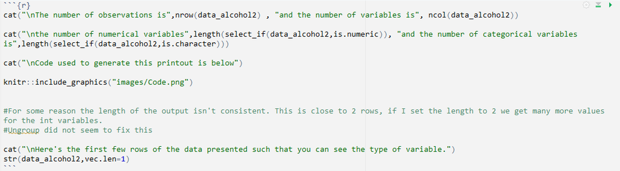

```r
knitr::include_graphics("images/Code.png")
```

```r
#For some reason the length of the output isn't consistent. This is close to 2 rows, if I set the length to 2 we get many more values for the int variables.
#Ungroup did not seem to fix this

cat("\nHere's the first few rows of the data presented such that you can see the type of variable.")
```

```
##
## Here's the first few rows of the data presented such that you can see the type of variable.
```

```r
str(data_alcohol2,vec.len=1)
```

```
## 'data.frame':    66 obs. of  5 variables:
##  $ Country          : chr  "Australia" ...
##  $ Year             : int  1890 1929 ...
##  $ SpiritsPercentage: int  43 20 ...
##  $ BeerPercentage   : int  47 62 ...
##  $ WinePercentage   : int  10 19 ...
```

## Data set summary

```r
group_by(data_alcohol2)
```

```
## # A tibble: 66 × 5
##    Country    Year SpiritsPercentage BeerPercentage WinePercentage
##    <chr>     <int>             <int>          <int>          <int>
##  1 Australia  1890                43             47             10
##  2 Australia  1929                20             62             19
##  3 Australia  1964                13             75             12
##  4 Australia  1984                12             64             24
##  5 Australia  2014                14             46             40
##  6 Austria    1964                15             55             30
##  7 Austria    1984                14             49             37
##  8 Austria    2014                14             51             35
##  9 Belgium    1890                35             62              3
## 10 Belgium    1929                12             81              8
## # ℹ 56 more rows
```

```r
#Group data frame by year
data_alcohol_grouped = data_alcohol2 %>% group_by(Year)

#Summarise Beer and Wine by their means across each year. This creates a 'mean of beer drunk per year'.
data_alcohol_grouped2 = data_alcohol_grouped %>% summarise_at(.vars = vars(BeerPercentage,WinePercentage),
               .funs = c(mean="mean"))
#Same process but for variance.
data_alcohol_grouped = data_alcohol_grouped %>% summarise_at(.vars = vars(BeerPercentage,WinePercentage),
               .funs = c(var="var"))
#Save results from above as vectors in dataframe
data_alcohol_grouped$BeerPercentage_mean=data_alcohol_grouped2$BeerPercentage_mean
data_alcohol_grouped$WinePercentage_mean=data_alcohol_grouped2$WinePercentage_mean
#Display data
kable(data_alcohol_grouped, caption = "Mean and variance of beer and wine across all countries over time.")
```

Mean and variance of beer and wine across all countries over time.

| Year | BeerPercentage_var | WinePercentage_var | BeerPercentage_mean | WinePercentage_mean |
| --- | --- | --- | --- | --- |
| 1890 | 573.9444 | 1345.8611 | 33.77778 | 27.88889 |
| 1929 | 1047.7778 | 1328.8611 | 39.44444 | 29.88889 |
| 1964 | 679.2958 | 694.1292 | 47.31250 | 20.56250 |
| 1984 | 323.9292 | 475.4292 | 44.93750 | 26.31250 |
| 2014 | 123.5833 | 231.6667 | 39.62500 | 36.75000 |

This data summary suggests that across all countries, the proportion of beer drunk rose over time and peaked in 1964, while wine rose, dipped in 1964, then continued to rise to its current record proportion. Both wine and beer saw a **sharp** decline in variance over time, indicating many countries converging towards a similar proportion of beer and wine drunk.

[figure not shown]

```r
#Convert data to long format so it's more easily graphed
data_alcohol_graph <- data_alcohol2 %>% pivot_longer(cols = c(BeerPercentage, WinePercentage,  SpiritsPercentage),
                           names_to = "Drink_Type")

#Generate GGplot. Very straightforward plot, the y-axis is the value of Beer/Wine/Spirits percentage which we summarised into one column when we made data long above. Colour by drink type, facet by country then label the information.
ggplot(data = data_alcohol_graph, aes(x = factor(Year))) +
  geom_point(aes(y=value,col=Drink_Type)) +
  facet_wrap(~Country) +
  labs(caption = "This simple graph allows an easy visualisation of trends over time. One graph is provided for each country. ",color="Type Of Drink\n") +
  scale_color_manual(labels = c("Beer", "Wine","Spirits"),values = c("blue", "red","black")) +
  xlab('Year') +
  ylab("Proportion Drunk")
```